# Seminar preparations

To get the most out of the seminar (my session anyway), it is highly recommended to install R and RStudio, if you have not already done so. It’s free and it takes a couple of minutes max. This allows you to follow along with the simple examples I’ll be providing.  
1. Install R - it works on Windows, Mac and Linux alike: https://cran.r-project.org/  
2. Install RStudio: https://www.rstudio.com/products/rstudio/download/  
Alternative: if you really don’t want to install those and are using Windows, at least install Notepad++ (https://notepad-plus-plus.org/) so you can view the markdown code with highlightning (useful).  
4. Try to run R. A shortcut probably appeared on the desktop, if not, find the executable (by default `C:\Program Files\R\R-3.x.x\bin\x64` -> `Rgui.exe` on 64bit Windows). You will see a relatively ugly window with a terminal, something like this:

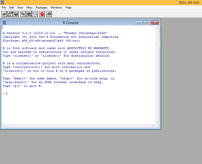

5. Good news is you won’t have to see the ugly version ever again, if you installed the nice and user friendly RStudio. Try to run it (probably a shortcut appeared, if not, check `C:\Program Files\RStudio\bin` -> `Rstudio.exe` by default on 64bit Windows). The R terminal/console now sits inside the RStudio interface.

[figure not shown]

6. Great. Try to create your first R Markdown document by navigating `File -> New File -> R Markdown` and press `OK` (somewhere along these steps a few extra packages might install automatically, be patient). A window/tab ‘Untitled.Rmd’ will appear with some example text in it. There is a little `Knit HTML` button above the text window, below the menu bar. Click it. Click it now! It will ask you to save the file - just save it whereever.

[figure not shown]

Congratulations, you just created your first R Markdown document and generated a website based on it. You will learn more at the seminar, on using this stuff to write reports and papers (books if you wish) and generate websites, all from the same code, with the integration of your research code. Obviously, this is most relevant for people already using R itself for research, but R Markdown can just as well be used without a single line of actual R in it - to create simple websites, generate bibliographies or typeset beautiful equations, to name a few examples.  
What if something didn’t work? Come 10 minutes early, we’ll fix it.